# Observational Research

PSCI 2270 - Week 11

Georgiy Syunyaev

Department of Political Science, Vanderbilt University

November 7, 2024

## Plan for this week

0. Project Updates
1. What if we cannot randomize?
2. Instrumental Variables: Colonial origins
3. Regression Discontinuity: Finding close elections
4. Differences-in-differences: Tabloid media in UK

# Any project updates?

# What if we cannot randomize?

## First-best: Experiments

- Key idea: Randomization of the treatment makes the treatment and control groups “identical” on average
- The two groups are expected to be similar in terms of all characteristics (both observed and unobserved)
  - Control group is similar to treatment group
  - Outcome in control group $\approx$ what would have happened to treatment group if they did not receive treatment
  - *vice versa*
- If we want to study effects of factor $X$ on $Y$ we would ideally want to run an experiment
  - But what do we do if we cannot randomize?
  - E.g. we do not have funding or phenomena we study, like elections, cannot be reasonably manipulated by researcher

## Second-best: “Natural” experiments

- Natural experiments: Effects of random or *as-if random* events/processes that occur outside of researcher’s control and are related to factors we are interested in
- Uses observational data, but is better than correlation
- What is the difference between random and *as-if random*?
  - Random: We can prove that the process/event was decided by *lottery* or analogous procedure and know the probabilities $\Rightarrow$ basically an experiment
  - As-if random: Process/event is **not random**, and we know it, but can show that it is unaffected by most factors that are linked to our outcomes

## Pioneer of as-if random

Jo n Snow (???-???) ?

[figure not shown]

JoHn Snow (1813 - 1858)!

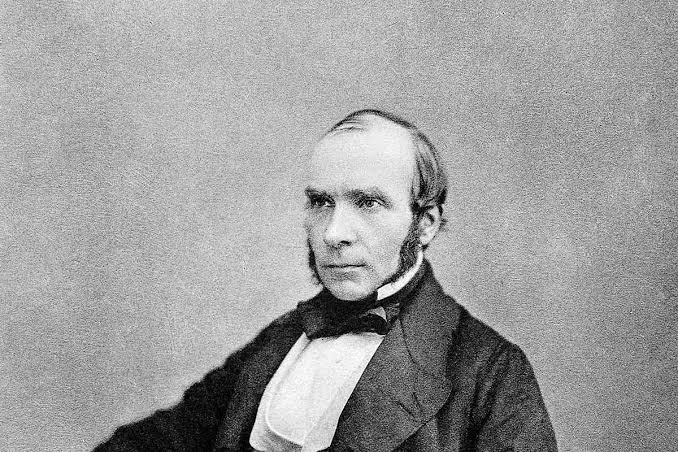

## As-if random cholera…

- Cholera outbreak in London in 1854 (!)

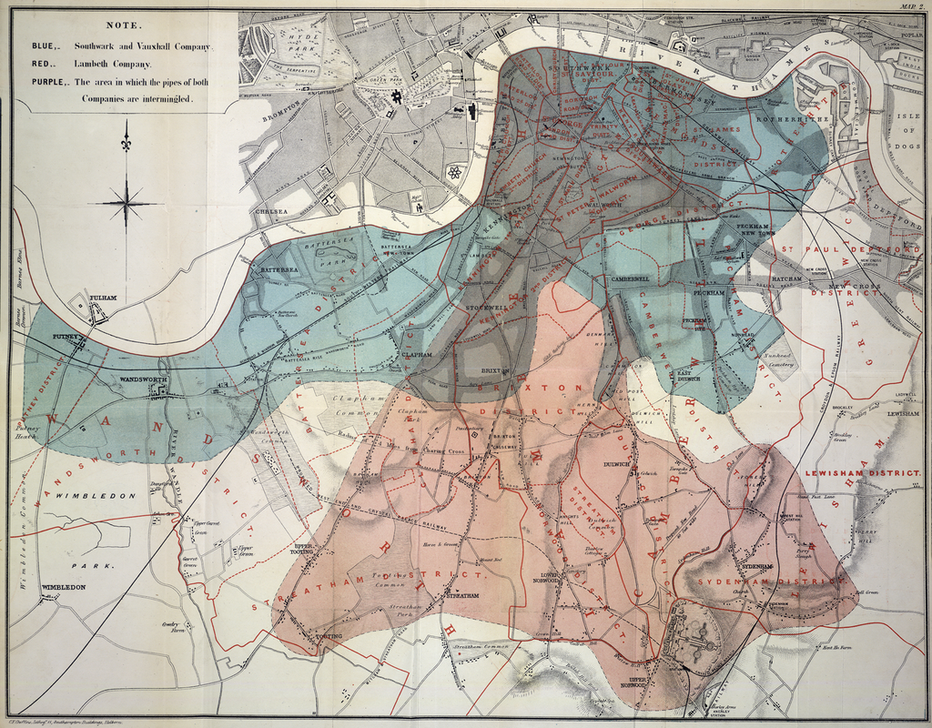

## Study

- Theories on cholera have two hypotheses of transmission: water or air
  - How would we test this experimentally?
  - How would we test this if we cannot randomize?
- As-if random event:
  - In one area of London where outbreak happened in 1854 two companies supply water
  - In 1852 Lambeth moved upstream $\Rightarrow$ possibly cleaner water
  - John Snow collected data on cholera deaths over 7 weeks

## Results

Deaths from cholera epidemic over 7 weeks, 1854

| **Water Supply Company** | **Number of Houses** | **Deaths From Cholera** | **Cholera Deaths per 10,000 Houses** |
| --- | --- | --- | --- |
| Southwark and Vauxhall | 40,046 | 1,263 | 315 |
| Lambeth | 26,107 | 98 | 37 |
| Rest of London | 256,423 | 1,422 | 59 |

- Evidence: Strong support for the water hypothesis!
- Was the exposure actually random?
  - Did companies choose strategically? No
  - Did people choose strategically? No
  - Are areas served by the company upstream different? No

## How to find natural experiments

- **Random:** Lotteries related to politically relevant processes; Timing of events
- **As-if random:** Borders and historical events
- *Process of looking for natural experiments is always creative, but there are some commonly used types*
- Let’s brainstorm this in groups!

## From Dunning (2012)

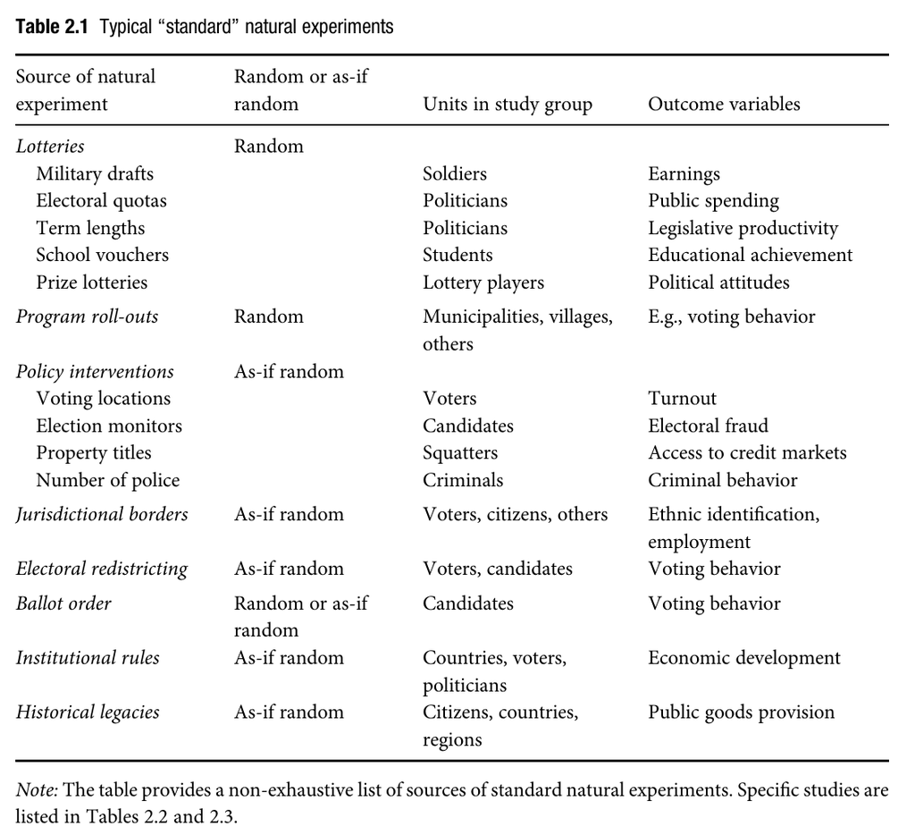

## Making as-if random

# Colonial origins of Comparative Development

## Colonial origins

- *“The Colonial Origins of Comparative Development: An Empirical Investigation”* Acemoglu, Johnson, and Robinson (2001) (18691 citations!)
- Summary:
  - Observational study on the long-term effects of colonial institutions on country development
  - Heavy use of historical data (historical political economy)
  - Institutions are not *randomly assigned*! Deal with this using instrumental variables
  - Colonial institutions persist over time and affect the income per capita today!

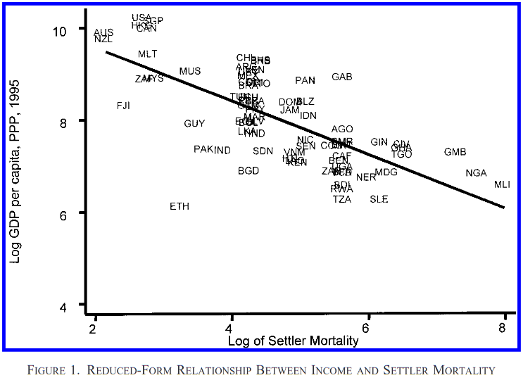

## Theory

- Question: Why are some countries rich and some are poor? ($Y$)
- Hypothesis: Extractive institutions ($X$) are persistent and can affect long-term development
- Searching for as-if random assignment:
  - Why countries have different institutions?
  - Some countries were forced into extractive institutions by colonialists
  - Are there *as-if random* reasons for setting extractive institutions?

## Instrumental variables

- What is an instrument: Some as-if randomly assigned factor that affects our main independent variable (early institutions) but is unlikely to affect our main outcome (current development) **directly**
  - What is the instrument in Acemoglu, Johnson, and Robinson (2001) ? Settler mortality!
- Instrument in Acemoglu, Johnson, and Robinson (2001):
  - (potential) settler mortality $\Rightarrow$ settlements $\Rightarrow$ early institutions $ $ current institutions $\Rightarrow$ current economic development

## How do we use instruments

- Instruments affects outcome only through independent variable $\Rightarrow$ Look at the effect of independent variable on outcomes *predicted* by instrument
  - $Z \rightarrow X \rightarrow Y$, but $Z \not\rightarrow Y$
  - Why the last part is important? Excludability!
- Instead of simple correlation we use two-stage procedure (2SLS)
  1. Predict the current instutitions using historical data on mortality/settlements
  2. Look at correlation between *predicted* institutions and economic development
- To prove that instrument is valid researcher needs:
  - Show that instrument indeed predicts independent variable
  - Provide evidence that instrument is unlikely to affect outcome directly

## How do they do it?

- How do they operationalize economic development ($Y$), institutions ($X$) and settlements/mortality ($Z$)?
- How do they prove that settlements did not affect economic development through other channels?
- What analyses do they run?

## Main results

- (potential) settler mortality/settlements $\Rightarrow$ early institutions $\Rightarrow$ current institutions

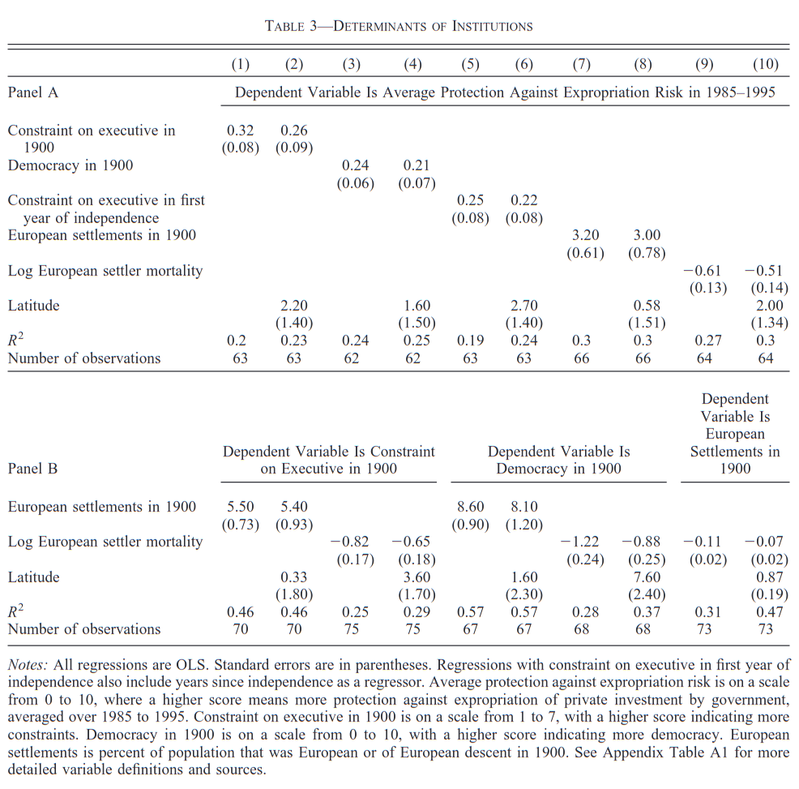

## Main results

- (potential) settler mortality/settlements $\Rightarrow$ current institutions $\Rightarrow$ current economic development

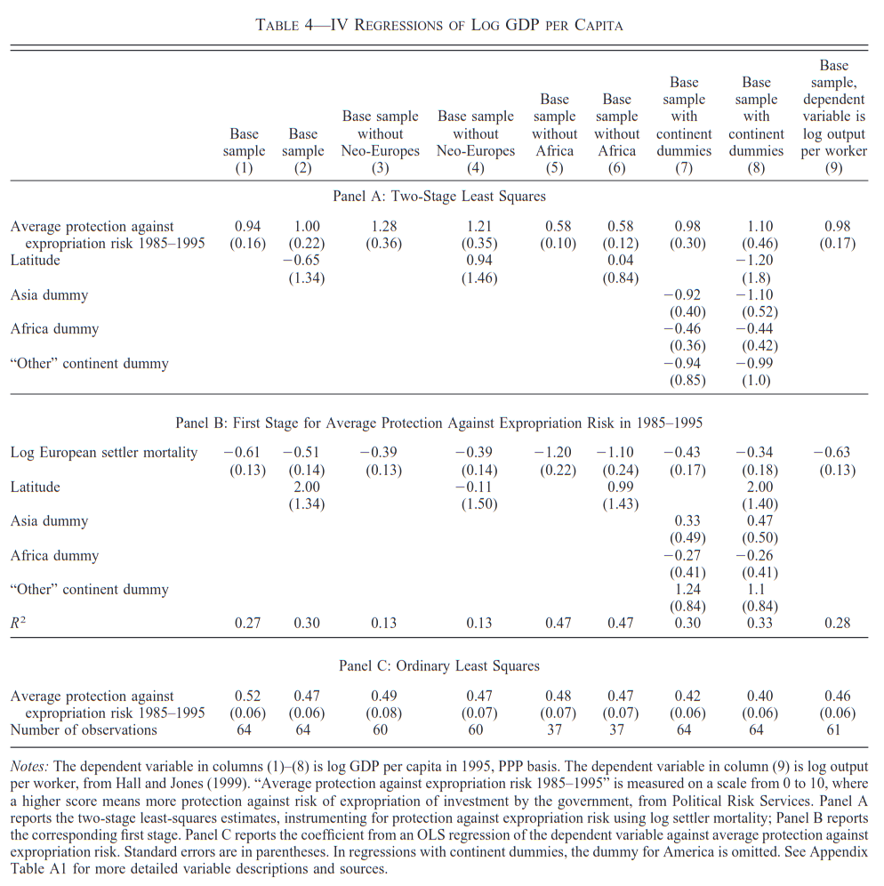

## Main critiques

- Albouy (2012)
  - Different sources of data [some predicted mortality, some direct measures] $\Rightarrow$ Selection bias
  - Data on troops (some in barracks and some on campaign) $\Rightarrow$ Selection bias
  - Why use data on troops at all if it is not the same as settlers $\Rightarrow$ Measurement validity
- Can settlers affect current levels of development not through institutions (Glaeser et al. 2004)? $\Rightarrow$ Violation of excludability
- What about post-colonial policies/economic changes (Easterly and Levine 2016)? $\Rightarrow$ Violation of excludability

## Nobel prize

[figure not shown]

# Final projects

## Final project structure

1. Introduction (2 pages)
   - Motivation/Background $\Rightarrow$ Literature review $\Rightarrow$ Research question $\Rightarrow$ Brief description of study and how it fits in the literature
2. Theory and Hypotheses (1-2 pages)
   - (Broad) Theoretical expectations $\Rightarrow$ (Concrete) Hypotheses you are planning to test
3. Research design (5-7 pages)
   - Setting and context $\Rightarrow$ Description of your sample $\Rightarrow$ What is your “treatment” $\Rightarrow$ Independent/dependent variables $\Rightarrow$ Measurement $\Rightarrow$ Estimation
4. Possible Issues (1-2 pages)
5. Appendix (😵‍💫 pages)
   - Code for simulation of data and simple analyses
   - Survey instruments and other details on measurement

# Back to observational stuff

## Discontinuity and DiD

- **Old problem:** We need to find units that vary in treatment but are very similar on all other dimensions
- **New solutions:**
  - RDD: Zoom in onto those who almost got “treatment” (control group) and those who just made it (treatment group)
  - DiD: Utilize some naturally occuring event that splits the sample into two groups and assume that if “treated” units would not receive “treatment” they would behave like “control” units

## Spot it

- Can you guess which plot is characteristic of which design?

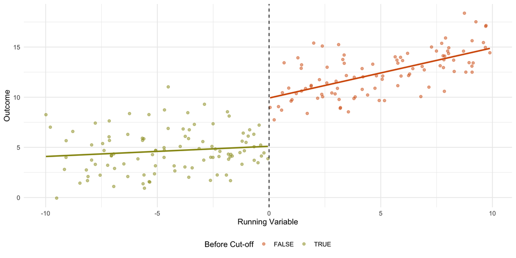

RDD design: “running variable” on X axis and outcome of interest on Y axis

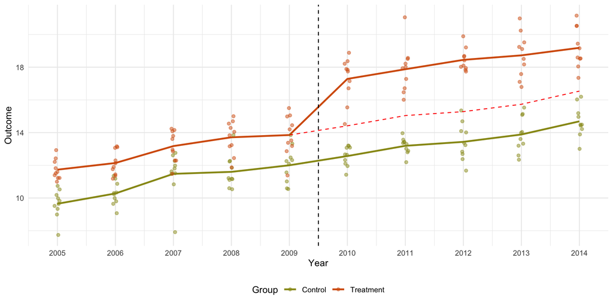

DiD design: trends in outcomes between “treated” and “control” units before and after the event *(and also projects what the “treated” units “untreated” potential outcomes would be)*

- What are the major issues to consider are with either of those designs?

# When extremists win primaries

## Primaries in the US

- *“What Happens When Extremists Win Primaries?”* Hall (2015)
- Summary:
  - Observational study on the short-/long-term effects of having extrimists run in general elections
  - Use primary to find comparable cases of when extrimists win and just lose
  - Having extrimists selected in primaries leads to lower chance of winning and lower representation

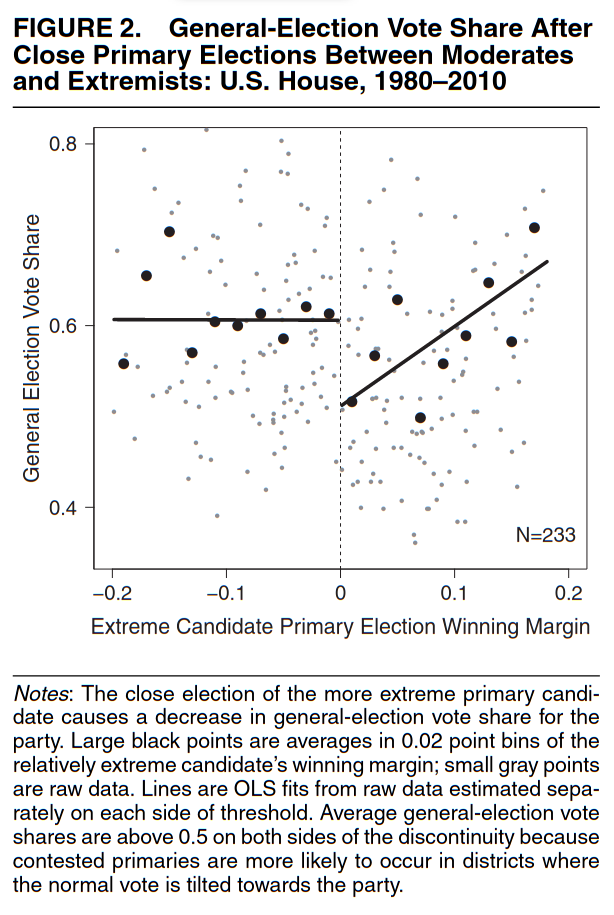

## Theory

- **Question:** Is having more ideologically extreme candidates good or bad for the party/voters?
- **Hypothesis:** More extreme party candidate today $\Rightarrow$ lower chances of winning today $\Rightarrow$ lower representation today / lower future incumbency advantage
- Searching for as-if random assignment:
  - We cannot just compare general election results since there is **selection bias**
  - But how do extremists get to general elections? Through primaries
  - Let’s look at when extremists win primaries and try to find “coin-flip” situation

## Making discontinuity

- We need to look at the elections that were almost won and just won by extremists $\Rightarrow$ Extremists vote share in primaries is running variable
- Two questions:
  1. How do we define extremists?
  2. What are the primaries where both extremists and moderates could win?

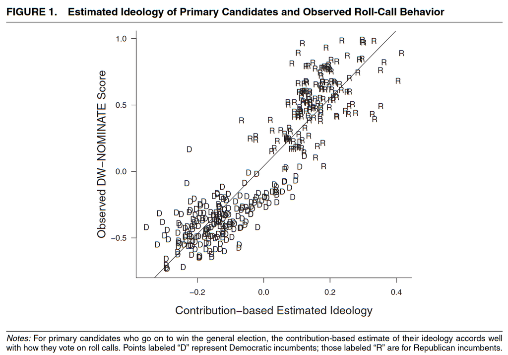

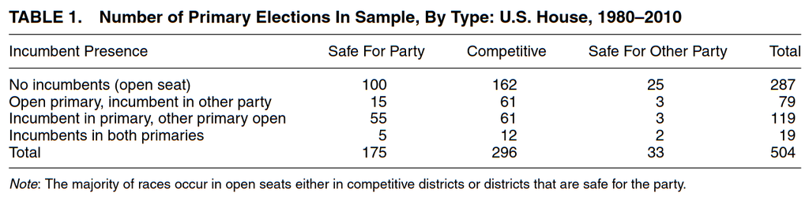

## Analysis

- They estimate the following regression:

$$\color{#98971a}{Y_{ipt}} = \beta_{0} + \color{#458588}{\beta_{1}} \color{#d65d0e}{\text{Extremist Primary Win}_{ipt}} + f(V_{ipt}) + \epsilon_{ipt}$$

- $i$ is usually unit within one time period, $t$ is usually time, $p$ - party
- **Outcome of interest:** vote share/victory/roll-call voting score
- **Treatment indicator:** whether extremist wins contested primaries (vs moderate) and proceeds to national elections
- **RDD treatment estimate**
- What is $f(V_{ipt})$?

## (Many) results

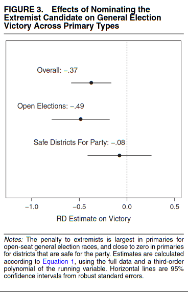

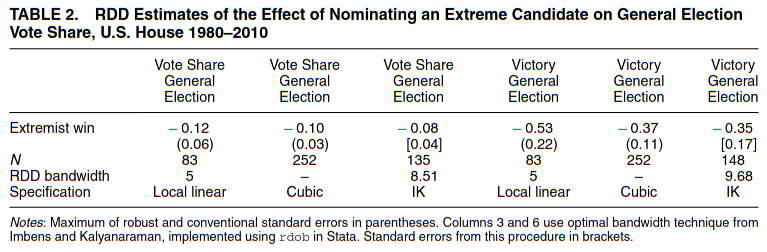

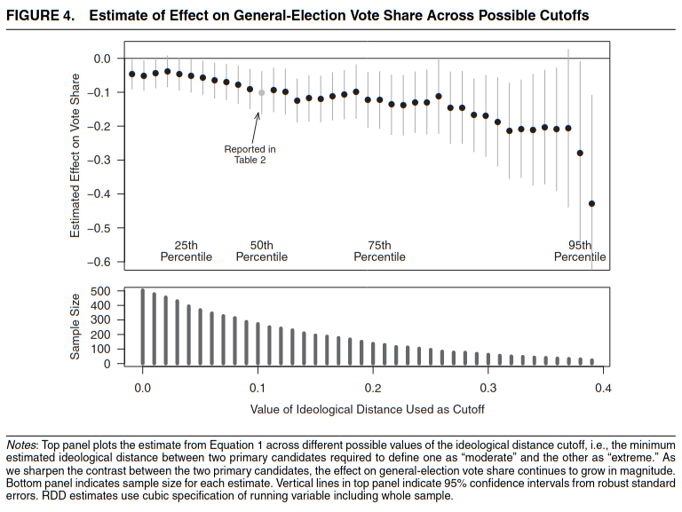

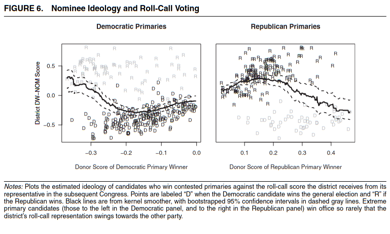

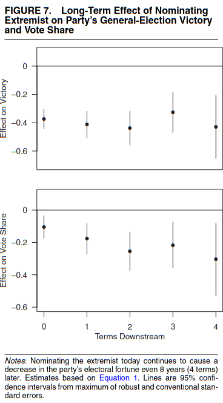

## Discussion

- What are possible issues here?
  - Excludability: Is there sorting around the cut-off?
  - External validity: Are extremists the same as moderates on anything besides ideology? Are distrcits with contested primaries different from others?
  - Measurement error: Lots of possibly imprecise measures (including gender ?!)…
- Still better than just a correlation analysis
- Great visual presentation of results!!

# Effects of S*n in UK

## Effects of S*n in UK

- *“Tabloid Media Campaigns and Public Opinion: Quasi-Experimental Evidence on Euroscepticism in England”* Foos and Bischof (2022)
- Summary:
  - Observational study on the long-term effects of exposure to tabloid media
  - Media consumption is not random, so they utilize local boycott of tabloid newspaper in Merseyside after the Hillsborough disaster
  - Show that decrease in exposure to tabloid media lead to large long-term decrease in support for leaving EU

[figure not shown]

## Theory

- **Question:** What are the long-term consequences of exposure to tabloid media?
- **Hypothesis:** Boycott of tabloid media $\Rightarrow$ less exposure to coverage of this tabloid media by youth and working class $\Rightarrow$ less support for leaving EU $\Rightarrow$ Less voting to leave EU during 2016 Referendum
- Searching for as-if random assignment:
  - Media consumption does not change drastically
  - We need to find a “shock” to media consumption/availability $\Rightarrow$ Boycott
  - Were reasons for boycott related to pro-/anti-EU debate?
  - Since Boycott is localized we can compare outcomes in areas with Boycott (Merseyside) to those without (Lancashire and Cheshire)

## Looking at differences in differences

- While Boycott is a shock to media consumption it is not random and is compound treatment (affects many things at once)
- Two questions:
  1. How do we show that it was a shock and where?
  2. How do we approximate what the outcomes would be, would there not be a shock? Parallel trends!

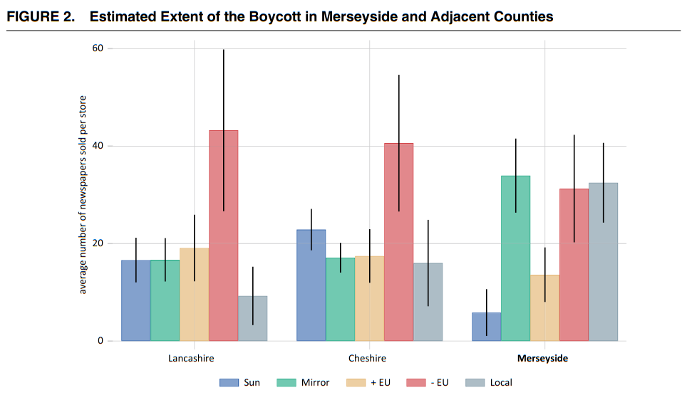

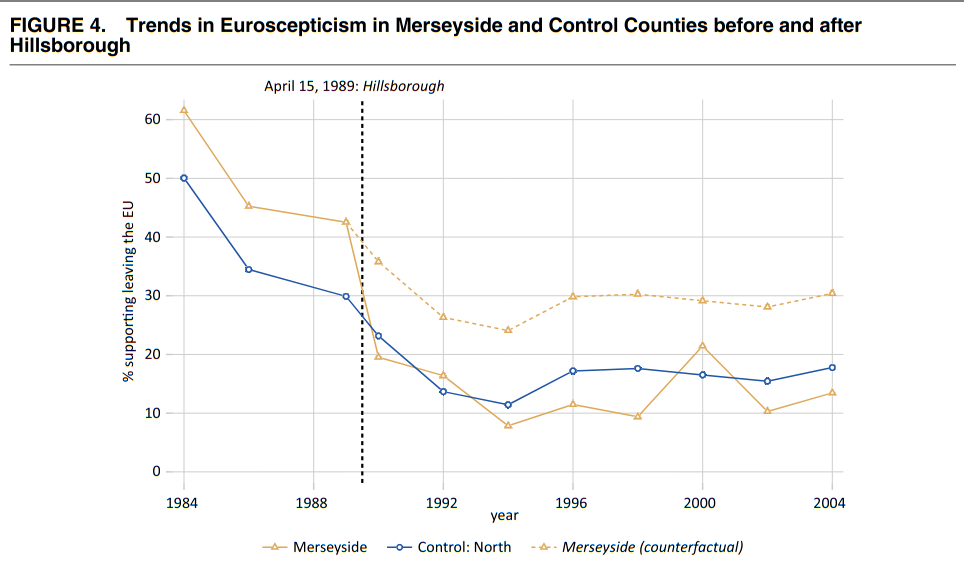

## Analysis

- They estimate the following regression:

$$\color{#98971a}{\text{leavingEU}_{i,c,t}} = \alpha_{c} + \gamma_{t} + \color{#458588}{\delta_{\text{DID}}} \color{#d65d0e}{T_{c,t}} + \varepsilon_{i,c,t}$$

- $i$ as before is unit (respondent) in one time period, $t$ is as before time, $c$ - constituency
- **Outcome of interest:** answer to question about support for leaving EU
- **Treatment indicator:** whether respondent resides in constituency in Merseyside after the Boycott start
- **DiD treatment estimate**
- What is $\alpha_{c}$ and $\gamma_{t}$?

## (Many) results

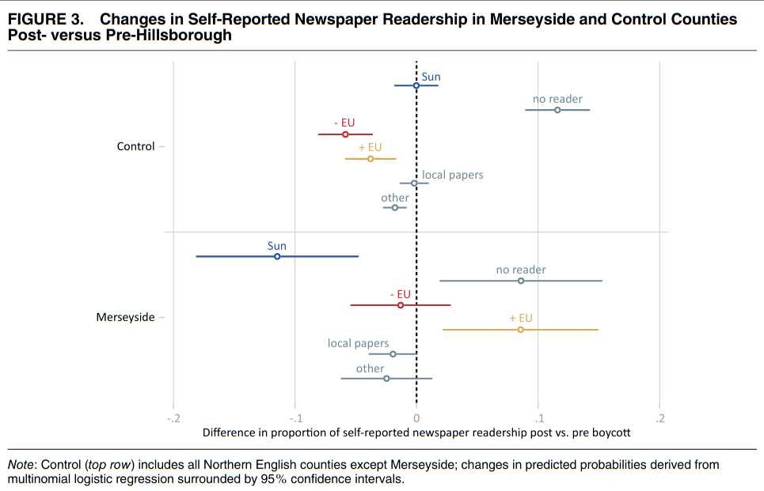

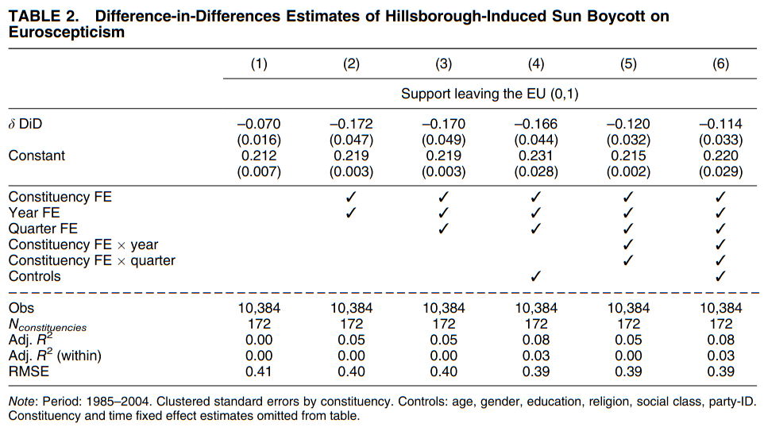

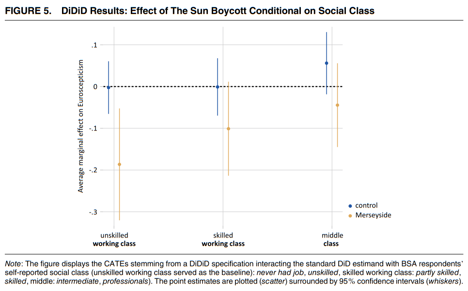

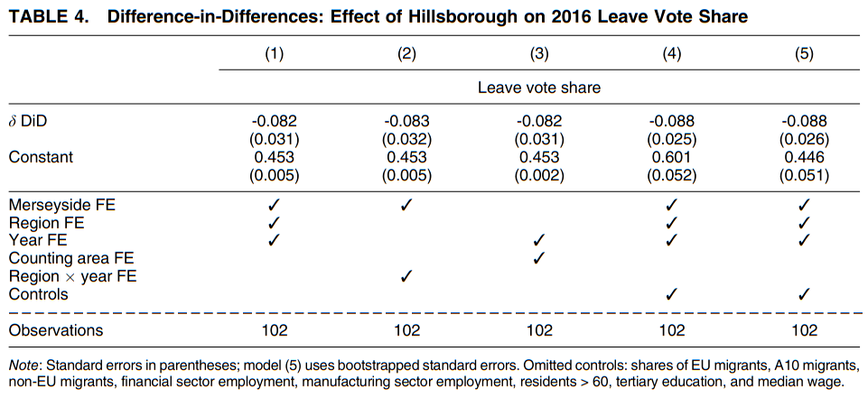

## Discussion

- What are possible issues here?
  - Compliance: Is it the case that Merseyside actually implemented Boycott?
  - Excludability: Boycott likely affected many things at the same time, do they answer this concern well?
  - Non-interference: Could Boycott in Merseyside affect exposure to Sun or its coverage in other places?
- Still better than just a correlation analysis

## Conclusion on observational studies

- With observational designs we are trying to approximate experiments to avoid confounding
- There is an ordering of designs in terms of **how persuasively they avoid confounding**:
  - *Pure correlation $<$ Controlling for possible confounders $<$ Instrumental variables $<$ RDD/DiD $<$ Natural experiments $<$ Randomized experiments*
- The order is often reversed if we are concerned about **naturalistic setting/long-term effects/Logistical costs**:
  - *Randomized experiments $<$ Natural experiments $<$ RDD/DiD/Instrumental variables $<$ Controlling for possible confounders $<$ Pure correlation*
- This is the main trade-off (and battle) faced by researchers conducting large-$N$ studies

# Next week: Ethical concerns and small-$N$ studies

## References

Acemoglu, Daron, Simon Johnson, and James A. Robinson. 2001. “The Colonial Origins of Comparative Development: An Empirical Investigation.” *American Economic Review* 91 (5): 13691401.

Albouy, David Y. 2012. “The Colonial Origins of Comparative Development: An Empirical Investigation: Comment.” *American Economic Review* 102 (6): 3059–76.

Dunning, Thad. 2012. *Natural Experiments in the Social Sciences: A Design-Based Approach*. Cambridge University Press.

Easterly, William, and Ross Levine. 2016. “The European Origins of Economic Development.” *Journal of Economic Growth* 21: 225–57.

Foos, Florian, and Daniel Bischof. 2022. “Tabloid Media Campaigns and Public Opinion: Quasi-Experimental Evidence on Euroscepticism in England.” *American Political Science Review* 116 (1): 1937.

Glaeser, Edward L, Rafael La Porta, Florencio Lopez-de-Silanes, and Andrei Shleifer. 2004. “Do Institutions Cause Growth?” *Journal of Economic Growth* 9: 271–303.

Hall, Andrew B. 2015. “What Happens When Extremists Win Primaries?” *American Political Science Review* 109 (1): 18–42. https://doi.org/10.1017/S0003055414000641.